# Report European Value Survey (EVS)

Stefan Zimmermann

16 6 2020

# Introduction

This project uses data from the European Value Study (EVS) and aims to examine attitudes towards gender roles and immigration for European countries. In the project report two variables on gender role and migration are descriptively examined and a first OLS regression is created. In a further step, the project report will not only provide first results for Europe, but also additional reports will be prepared, which will help to identify possible differences within the EU.

# Data Preparation

During data preparation, the required EVS datasets (ZA7500) are unzipped, downloaded and prepared for regression and descriptive analysis. Furthermore, the data set is reduced to the research-relevant variables.

# Summary Statistics

| **No** | **Variable** | **Stats / Values** | **Freqs (% of Valid)** | **Graph** | **Valid** | **Missing** |
| --- | --- | --- | --- | --- | --- | --- |
| 1 | id_cocas [numeric] | Mean (sd) : 2017705000538.9 (310.6) min < med < max: 2017705000001 < 2017705000539 < 2017705001076 IQR (CV) : 537 (0) | 1075 distinct values |  | 1075 (100%) | 0 (0%) |
| 2 | year [factor] | 1. 2017 2. 2018 3. 2019 | 1075 ( 100.0% ) 0 ( 0.0% ) 0 ( 0.0% ) |  | 1075 (100%) | 0 (0%) |
| 3 | age [numeric] | Mean (sd) : 50.6 (18.1) min < med < max: 18 < 51 < 82 IQR (CV) : 29 (0.4) | 65 distinct values |  | 1075 (100%) | 0 (0%) |
| 4 | age_r [factor] | 1. 15-24 years 2. 25-34 years 3. 35-44 years 4. 45-54 years 5. 55-64 years 6. 65 and more years | 104 ( 9.7% ) 138 ( 12.8% ) 177 ( 16.5% ) 174 ( 16.2% ) 210 ( 19.5% ) 272 ( 25.3% ) |  | 1075 (100%) | 0 (0%) |
| 5 | age_r2 [factor] | 1. 15-29 years 2. 30-49 years 3. 50 and more years | 167 ( 15.5% ) 342 ( 31.8% ) 566 ( 52.6% ) |  | 1075 (100%) | 0 (0%) |
| 6 | age_r3 [factor] | 1. 18-24 years 2. 25-34 years 3. 35-44 years 4. 45-54 years 5. 55-64 years 6. 65-74 years 7. 75 and more years | 104 ( 9.7% ) 138 ( 12.8% ) 177 ( 16.5% ) 174 ( 16.2% ) 210 ( 19.5% ) 152 ( 14.1% ) 120 ( 11.2% ) |  | 1075 (100%) | 0 (0%) |
| 7 | country [factor] | 1. Albania 2. Azerbaijan 3. Austria 4. Armenia 5. Bosnia and Herzegovina 6. Bulgaria 7. Belarus 8. Croatia 9. Czechia 10. Denmark [ 24 others ] | 0 ( 0.0% ) 0 ( 0.0% ) 0 ( 0.0% ) 0 ( 0.0% ) 0 ( 0.0% ) 0 ( 0.0% ) 0 ( 0.0% ) 0 ( 0.0% ) 0 ( 0.0% ) 0 ( 0.0% ) 1075 ( 100.0% ) |  | 1075 (100%) | 0 (0%) |
| 8 | v72 [factor] | 1. agree strongly 2. agree 3. disagree 4. disagree strongly | 48 ( 4.5% ) 263 ( 24.8% ) 581 ( 54.9% ) 167 ( 15.8% ) |  | 1059 (98.51%) | 16 (1.49%) |
| 9 | v80 [factor] | 1. agree strongly 2. agree 3. neither agree nor disagre 4. disagree 5. disagree strongly | 281 ( 26.4% ) 477 ( 44.8% ) 134 ( 12.6% ) 146 ( 13.7% ) 27 ( 2.5% ) |  | 1065 (99.07%) | 10 (0.93%) |
| 10 | v225 [factor] | 1. male 2. female | 468 ( 43.5% ) 607 ( 56.5% ) |  | 1075 (100%) | 0 (0%) |
| 11 | v243_ISCED_1 [factor] | 1. Less than primary 2. Primary 3. Lower secondary 4. Upper secondary 5. Post-secondary non tertia 6. Short-cycle tertiary · 7. Bachelor or equivalent 8. Master or equivalent 9. Doctoral or equivalent… | 1 ( 0.1% ) 24 ( 2.2% ) 152 ( 14.2% ) 567 ( 53.0% ) 0 ( 0.0% ) 70 ( 6.6% ) 224 ( 20.9% ) 23 ( 2.1% ) 8 ( 0.8% ) 0 ( 0.0% ) |  | 1069 (99.44%) | 6 (0.56%) |
| 12 | v243_EISCED [factor] | 1. No formal or less than pr 2. I - Primary education 3. II - Lower secondary (inc 4. IIIb - Upper secondary wi 5. IIIa - Upper secondary wi 6. IV - Post-secondary/advan 7. V1 - Bachelor's level 8. V2… | 1 ( 0.1% ) 24 ( 2.2% ) 152 ( 14.2% ) 226 ( 21.1% ) 341 ( 31.9% ) 70 ( 6.6% ) 224 ( 20.9% ) 31 ( 2.9% ) |  | 1069 (99.44%) | 6 (0.56%) |
| 13 | v243_r [factor] | 1. lower 2. medium 3. higher | 177 ( 16.6% ) 567 ( 53.0% ) 325 ( 30.4% ) |  | 1069 (99.44%) | 6 (0.56%) |
| 14 | age_square [numeric] | Mean (sd) : 2884.8 (1851) min < med < max: 324 < 2601 < 6724 IQR (CV) : 2929 (0.6) | 65 distinct values |  | 1075 (100%) | 0 (0%) |

**Descriptive statistics** of EVS Data: doi:10.4232/1.13511

# Descriptive Statistics

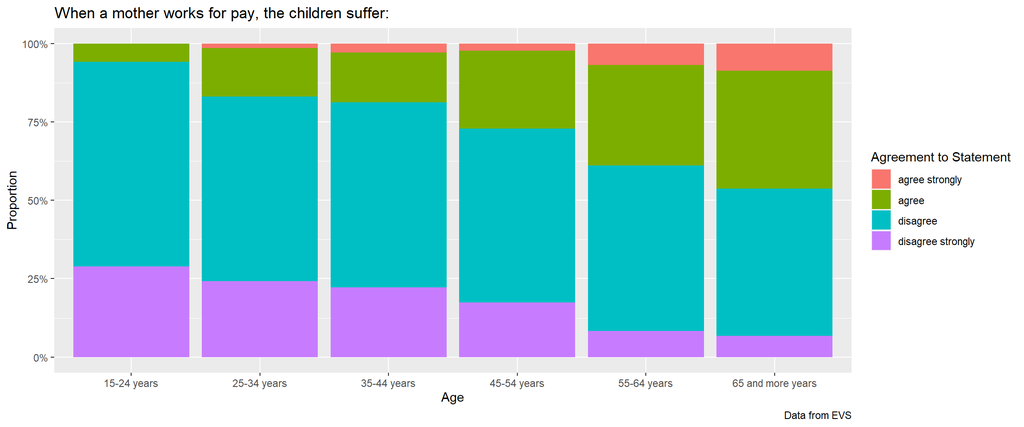

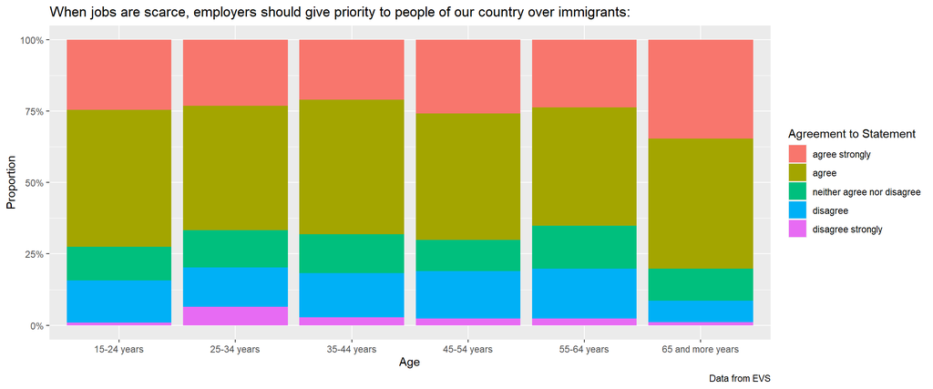

# OLS Regression on v72 (Model 1) and v80 (Model 2)

The coefficient Estimate contains six rows; the first one is the intercept. The intercept, in both models, is the expected value 3.381919(model1) 1.9082847 (model2) of v72/v80 for agreeing to the statement if we consider the independent variables as 0. The next rows describe the Coefficients, or in both models, the effect of the predictors. The slope term of sex in our model is saying if a change of gender to female happens, the y variable increases in model 1 by 0.1111661 and decreases in model 2 by -0.0576291. The p-value of this coefficient of model 1 is 0.0109865, so the p-value is significant. The p-value of this coefficient of model 2 is 0.3716985, so the p-value is not significant. A small p-value indicates that it is unlikely we will observe a relationship between the predictor and response (v72 or v80) variables due to chance. Typically, a p-value of 0.05 or less is a good cut-off point. Three stars represent a highly significant p-value. Consequently, a small p-value for the intercept and the coefficients indicates that we can reject the null hypothesis which allows us to conclude that there is a relationship between predictor and response.

OLS Regression on v72 (Model 1) and v80 (Model 2)

|  | Model 1 | Model 2 |
| --- | --- | --- |
| Intercept | 3.38 (0.17)* | 1.91 (0.25)* |
| Age | -0.02 (0.01)* | 0.01 (0.01) |
| Age Squared | 0.00 (0.00) | -0.00 (0.00) |
| Sex: Female | 0.11 (0.04)* | -0.06 (0.06) |
| Medium Education Level | 0.06 (0.06) | 0.12 (0.09) |
| High Education Level | 0.31 (0.07)* | 0.58 (0.10)* |
| R<sup>2</sup> | 0.14 | 0.06 |
| Adj. R<sup>2</sup> | 0.14 | 0.06 |
| Num. obs. | 1053 | 1059 |

*p < 0.05